# run_MORA_salt_slugs

KEC

2026-09-09

This rmd processes slug test data collected along Edith Creek and the Paradise River at Mount Rainier during September 2026. The workflow can be easily adapted to other sites, but it is written specifically for the Mount Rainier effort.

```r
# ---------------------------------------------------------------------------- #
# Salt slug test analysis
# Written for AquaTROLL 200 and 600 output logs
# Methods from:
# Moore, R. D. (2005). Slug injection using salt in solution.
# Streamline Watershed Management Bulletin, 8(2), 1-6.
# ---------------------------------------------------------------------------- #

#' Read a logger CSV, auto-detecting how many header lines to skip
#'
#' AquaTROLL 200/600 exports carry a variable number of metadata lines
#' before the real header row. That header row's first column is always
#' some form of a timestamp field ("Date Time", "Time", any case), so this
#' scans for it instead of relying on a hard-coded `skip` count. Matching
#' requires the field to be followed by a comma, so metadata lines that
#' merely mention "time" (e.g. a "Time Zone: ..." line) aren't mistaken
#' for the header.
#'
#' @param file_path Path to the logger CSV.
#' @param max_header_lines Number of lines to scan while looking for the
#'   header row. Defaults to 100; raise it if a logger ever ships with a
#'   longer metadata block.
#'
#' @return A tibble, as from `read_csv()`.
read_slug_log <- function(file_path, max_header_lines = 100) {

  header_scan <- read_lines(file_path, n_max = max_header_lines)
  header_row <- which(str_detect(
    header_scan,
    regex('^"?\\s*(date\\s*time|time)\\s*"?\\s*,', ignore_case = TRUE)
  ))[1]

  if (is.na(header_row)) {
    stop(str_glue(
      "Couldn't find a header row starting with a \"Date Time\" or \"Time\" column in the ",
      "first {max_header_lines} lines of {file_path}. Try increasing `max_header_lines`."
    ))
  }

  read_csv(file_path, skip = header_row - 1, show_col_types = FALSE)
}

#' Derive a log name from a file path
#'
#' Takes whatever is after the last "/" and before the ".csv", e.g.
#' "data/.../SpringCreek_AT200_Slug1_ActualCond_output.csv" becomes
#' "SpringCreek_AT200_Slug1_ActualCond_output".
#'
#' @param file_path Path to the logger CSV.
#'
#' @return A single string.
get_log_name <- function(file_path) {
  tools::file_path_sans_ext(basename(file_path))
}

#' Derive slug mass (grams) from a file name
#'
#' Files are named so the segment after the final "_" and before ".csv"
#' is the salt mass in grams, e.g. "at200_slug1_400.csv" -> 400.
#'
#' @param file_path Path to the logger CSV.
#'
#' @return The slug mass, in grams, as a number.
get_slug_mass_from_filename <- function(file_path) {
  log_name <- get_log_name(file_path)
  mass_str <- str_extract(log_name, "[^_]+$")
  mass <- suppressWarnings(as.numeric(mass_str))

  if (is.na(mass)) {
    stop(str_glue(
      "Couldn't parse a slug mass from the end of \"{log_name}\" (got \"{mass_str}\"). ",
      "Pass `slug_mass` directly instead."
    ))
  }

  mass
}

#' Find the timestamp column in a cleaned data frame
#'
#' Matches a column named exactly "time" or "date_time" (post
#' `janitor::clean_names()`), case-insensitively.
#'
#' @param data A data frame that has already been through `clean_names()`.
#'
#' @return The matching column name, as a string.
get_time_column <- function(data) {
  matches <- names(data)[str_detect(names(data), regex("^(date_)?time$", ignore_case = TRUE))]

  if (length(matches) == 0) {
    stop(str_glue(
      "No time column found (expected \"time\" or \"date_time\"). ",
      "Available columns: {str_c(names(data), collapse = ', ')}"
    ))
  }

  matches[1]
}

#' Find a conductivity column in a cleaned data frame
#'
#' AquaTROLL exports carry both an "Actual Conductivity" and a "Specific
#' Conductivity" column, and `janitor::clean_names()` appends the sensor's
#' units and serial number to each (e.g. "actual_conductivity_m_s_cm_1351721").
#' That suffix varies by logger, so this matches on the required prefix only
#' — it works whether or not units are listed and regardless of the serial
#' number.
#'
#' @param data A data frame that has already been through `clean_names()`.
#' @param cond_type Which conductivity column to use: "specific_conductivity"
#'   (temperature-compensated) or "actual_conductivity" (raw reading).
#'
#' @return The matching column name, as a string.
select_cond_column <- function(data, cond_type = c("specific_conductivity", "actual_conductivity")) {
  cond_type <- match.arg(cond_type)

  matches <- names(data)[str_detect(names(data), regex(str_c("^", cond_type), ignore_case = TRUE))]

  if (length(matches) == 0) {
    stop(str_glue(
      "No column starting with \"{cond_type}\" found. ",
      "Available columns: {str_c(names(data), collapse = ', ')}"
    ))
  }
  if (length(matches) > 1) {
    warning(str_glue(
      "Multiple columns start with \"{cond_type}\": {str_c(matches, collapse = ', ')}. ",
      "Using the first: {matches[1]}"
    ))
  }

  matches[1]
}

#' Detect background conductivity from the pre-breakthrough baseline
#'
#' Walks through the record and, for each point, compares it to the mean
#' and SD of every point that came before it. The breakthrough is flagged
#' at the first point that rises above that running baseline by more than
#' `threshold_sd` SDs (or `min_rise` uS/cm, whichever is larger, so a
#' near-zero baseline SD can't trigger a false positive on tiny noise).
#' Background conductivity is then the mean of everything before that point.
#'
#' @param data Data frame with `time` and `cond` columns (already cleaned).
#' @param min_baseline_n Minimum number of points required before
#'   breakthrough can be flagged. Defaults to 30.
#' @param threshold_sd Number of baseline SDs a point must exceed to count
#'   as the start of breakthrough. Defaults to 6.
#' @param min_rise Minimum absolute rise (uS/cm) above baseline required,
#'   regardless of SD. Defaults to 5.
#'
#' @return A list with `bck_cond`, `breakthrough_row`, and `breakthrough_time`.
detect_bck_cond <- function(data, min_baseline_n = 30, threshold_sd = 6, min_rise = 5) {

  baseline_check <- data %>%
    mutate(
      row_id = row_number(),
      cum_mean = cummean(cond),
      cum_sumsq = cumsum(cond^2),
      cum_var = (cum_sumsq - row_id * cum_mean^2) / pmax(row_id - 1, 1),  # sample variance
      cum_sd = sqrt(pmax(cum_var, 0)),
      baseline_mean = lag(cum_mean),   # mean of all points BEFORE this row
      baseline_sd = lag(cum_sd),       # sd of all points BEFORE this row
      rise_threshold = pmax(threshold_sd * baseline_sd, min_rise),
      is_rise = row_id > min_baseline_n & cond > (baseline_mean + rise_threshold)
    )
```

```r
  breakthrough_row <- which(baseline_check$is_rise)[1]

  if (is.na(breakthrough_row)) {
    stop("No breakthrough detected in the data — check the log, or loosen `threshold_sd`/`min_rise`.")
  }

  list(
    bck_cond = baseline_check$baseline_mean[breakthrough_row],
    breakthrough_row = breakthrough_row,
    breakthrough_time = baseline_check$time[breakthrough_row]
  )
}

#' Run a salt slug discharge calculation
#'
#' Subtracts background conductivity, integrates the breakthrough curve
#' with the trapezoidal rule, and solves for streamflow discharge. Because
#' the correction factor enters the calculation as a simple multiplier,
#' discharge is inversely proportional to it — a higher correction factor
#' concentrates more mass per uS/cm and yields a lower discharge estimate.
#' That relationship is used below to turn a +/- range on the correction
#' factor into a discharge range without re-running the integration.
#'
#' @param data Raw logger data frame (e.g. from `read_slug_log()`). Must
#'   contain a time column and a conductivity column matching `cond_type`.
#' @param slug_mass Mass of salt injected, in grams. Leave as NULL (default)
#'   to auto-detect it from `file_path`'s file name (the segment after the
#'   final "_" and before ".csv", e.g. "..._400.csv" -> 400); pass a number
#'   to override auto-detection with a manually assigned mass.
#' @param file_path Path to the source CSV, used to auto-detect `slug_mass`
#'   when it isn't supplied directly. Not needed if `slug_mass` is given.
#' @param cond_type Which conductivity column to use: "specific_conductivity"
#'   (temperature-compensated, the default) or "actual_conductivity" (raw
#'   reading). Matched flexibly against the column names — see
#'   `select_cond_column()`.
#' @param bck_cond Background specific conductivity, in uS/cm. Leave as NULL
#'   (default) to auto-detect it from the stable period before breakthrough;
#'   pass a number to override auto-detection with a manually read value.
#' @param correction_factor Best-estimate conductivity-to-concentration
#'   correction factor (uS/cm -> mg/L). Defaults to 0.5.
#' @param correction_factor_range Uncertainty on `correction_factor`, used to
#'   compute a discharge range. Either a single number for a symmetric +/-
#'   offset (e.g. 0.02 for 0.5 +/- 0.02), or a length-2 vector giving explicit
#'   low/high correction factors (e.g. c(0.47, 0.53)). Leave NULL (default)
#'   to skip the range and report only a point estimate.
#' @param dt Logger interval, in seconds. Defaults to 1.
#' @param min_baseline_n,threshold_sd,min_rise Passed to `detect_bck_cond()`
#'   when `bck_cond` is not supplied.
#'
#' @return A list with:
#'   sensor_data: the cleaned data frame with concentration and
#'     integration columns added (at the point-estimate correction factor)
#'   discharge_Ls, discharge_cfs: point-estimate discharge, in L/s and ft3/s
#'   discharge_range_Ls, discharge_range_cfs: length-2 low/high discharge
#'     range (NULL if correction_factor_range was not supplied)
#'   correction_factor, correction_factor_range: the correction factor(s) used
#'   cond_type: the conductivity type used
#'   slug_mass: the slug mass used, in grams (detected or supplied)
#'   bck_cond: the background conductivity used (detected or supplied)
#'   breakthrough_time: time breakthrough was detected (NA if bck_cond
#'     was supplied manually)
run_salt_slug <- function(data, slug_mass = NULL, file_path = NULL,
                           cond_type = c("specific_conductivity", "actual_conductivity"),
                           bck_cond = NULL, correction_factor = 0.5,
                           correction_factor_range = NULL, dt = 1,
                           min_baseline_n = 30, threshold_sd = 6, min_rise = 5) {

  cond_type <- match.arg(cond_type)

  if (is.null(slug_mass)) {
    if (is.null(file_path)) {
      stop("Provide either `slug_mass` directly, or `file_path` so it can be auto-detected from the file name.")
    }
    slug_mass <- get_slug_mass_from_filename(file_path)
  }

  cleaned_data <- data %>% janitor::clean_names()
  time_col <- get_time_column(cleaned_data)
  cond_col <- select_cond_column(cleaned_data, cond_type)

  sensor_data <- cleaned_data %>%
    select(time = all_of(time_col), cond = all_of(cond_col))

  breakthrough_time <- as.POSIXct(NA)
  if (is.null(bck_cond)) {
    baseline <- detect_bck_cond(sensor_data, min_baseline_n = min_baseline_n,
                                 threshold_sd = threshold_sd, min_rise = min_rise)
    bck_cond <- baseline$bck_cond
    breakthrough_time <- baseline$breakthrough_time
  }

  sensor_data <- sensor_data %>%
    mutate(
      dt = dt,
      conc_bck_corr = if_else(cond > bck_cond, cond - bck_cond, 0),                     # uS/cm above background
      corr_dt = if_else(row_number() == 1, 0, (conc_bck_corr + lag(conc_bck_corr)) / 2 * dt), # trapezoidal rule, uS*s/cm (correction-factor independent)
      conc_mgl = conc_bck_corr * correction_factor,                                     # uS/cm -> mg/L, at point-estimate correction factor
      concdt = if_else(row_number() == 1, 0, (conc_mgl + lag(conc_mgl)) / 2 * dt)       # trapezoidal rule, mg*s/L
    )

  sum_corr_dt <- sum(sensor_data$corr_dt)  # uS*s/cm, independent of correction factor

  # discharge (L/s) as a function of correction factor: slug_mass (g) / (sum_corr_dt * cf / 1000) (g*s/L)
  discharge_for_cf <- function(cf) slug_mass / (sum_corr_dt * cf / 1000)

  discharge_Ls <- discharge_for_cf(correction_factor)

  cf_bounds <- NULL
  discharge_range_Ls <- NULL
  if (!is.null(correction_factor_range)) {
    cf_bounds <- if (length(correction_factor_range) == 1) {
      correction_factor + c(-1, 1) * correction_factor_range
    } else {
      range(correction_factor_range)
    }
    discharge_range_Ls <- sort(discharge_for_cf(cf_bounds))  # lower cf -> higher discharge
  }

  ls_to_cfs <- 0.0353147  # L/s -> ft3/s
  discharge_cfs <- discharge_Ls * ls_to_cfs
  discharge_range_cfs <- if (!is.null(discharge_range_Ls)) discharge_range_Ls * ls_to_cfs else NULL
```

```r
  list(
    sensor_data = sensor_data,
    discharge_Ls = discharge_Ls,
    discharge_cfs = discharge_cfs,
    discharge_range_Ls = discharge_range_Ls,
    discharge_range_cfs = discharge_range_cfs,
    correction_factor = correction_factor,
    correction_factor_range = cf_bounds,
    cond_type = cond_type,
    slug_mass = slug_mass,
    bck_cond = bck_cond,
    breakthrough_time = breakthrough_time
  )
}

#' Format a discharge label in L/s and ft3/s, with an optional range
#'
#' @param discharge_Ls,discharge_cfs Point-estimate discharge, in L/s and ft3/s.
#' @param discharge_range_Ls,discharge_range_cfs Optional length-2 low/high
#'   discharge ranges, in L/s and ft3/s. Leave NULL to omit the range.
#'
#' @return A single formatted string.
format_discharge_label <- function(discharge_Ls, discharge_cfs,
                                    discharge_range_Ls = NULL, discharge_range_cfs = NULL) {
  ls_txt <- sprintf("%.3f L/s", discharge_Ls)
  cfs_txt <- sprintf("%.3f ft³/s", discharge_cfs)

  if (!is.null(discharge_range_Ls)) {
    ls_txt <- str_glue("{ls_txt} ({sprintf('%.3f', discharge_range_Ls[1])}–{sprintf('%.3f', discharge_range_Ls[2])})")
    cfs_txt <- str_glue("{cfs_txt} ({sprintf('%.3f', discharge_range_cfs[1])}–{sprintf('%.3f', discharge_range_cfs[2])})")
  }

  str_glue("{ls_txt}   |   {cfs_txt}")
}

#' Plot a salt slug breakthrough curve
#'
#' @param sensor_data Data frame from run_salt_slug()$sensor_data.
#' @param bck_cond Background specific conductivity, in uS/cm.
#' @param discharge_Ls,discharge_cfs Point-estimate discharge, in L/s and
#'   ft3/s (shown in the plot subtitle).
#' @param log_name Site/log name, used in the plot title.
#' @param breakthrough_time Optional; time breakthrough was detected. Drawn
#'   as a vertical line if supplied and not NA.
#' @param discharge_range_Ls,discharge_range_cfs Optional length-2 low/high
#'   discharge ranges, in L/s and ft3/s, shown alongside the point estimate.
#' @param cond_type Optional; which conductivity column was used (e.g.
#'   "specific_conductivity"). Appended to the title if supplied, so plots
#'   from the same log run under different `cond_type`s are distinguishable.
#'
#' @return A ggplot object.
plot_breakthrough <- function(sensor_data, bck_cond, discharge_Ls, discharge_cfs, log_name,
                               breakthrough_time = NA,
                               discharge_range_Ls = NULL, discharge_range_cfs = NULL,
                               cond_type = NULL) {
  p <- ggplot(sensor_data, aes(x = time, y = cond)) +
    geom_line() +
    geom_hline(yintercept = bck_cond, linetype = "dashed", color = "red")

  if (!is.na(breakthrough_time)) {
    p <- p + geom_vline(xintercept = breakthrough_time, linetype = "dotted", color = "blue")
  }

  plot_title <- if (!is.null(cond_type)) str_glue("{log_name} ({cond_type})") else log_name

  p +
    labs(
      y = expression(paste("Specific Conductivity (", mu, "S/cm)")),
      title = plot_title,
      subtitle = format_discharge_label(discharge_Ls, discharge_cfs, discharge_range_Ls, discharge_range_cfs)
    ) +
    theme_bw()
}

#' Run salt slug analysis on every CSV in a folder
#'
#' Loops over every .csv file in `folder_path`, runs `read_slug_log()` and
#' `run_salt_slug()` on each with a shared slug mass / correction factor,
#' and returns one summary row per file. A file that fails (e.g. no
#' breakthrough detected, or no correction factor found) doesn't stop the
#' batch — its `error` column is filled in and the rest continue. Optionally
#' saves each file's breakthrough plot and processed sensor data, same as a
#' single run.
#'
#' @param folder_path Folder containing the logger CSVs.
#' @param slug_mass Mass of salt injected, in grams. Leave as NULL (default)
#'   to auto-detect it per file from each file name (the segment after the
#'   final "_" and before ".csv"); pass a number to use that fixed mass for
#'   every file instead, overriding auto-detection.
#' @param cond_type Which conductivity column to use: "specific_conductivity"
#'   (default) or "actual_conductivity". Passed through to `run_salt_slug()`.
#' @param correction_factor,correction_factor_range Fixed values passed to
#'   `run_salt_slug()` for every file. Ignored for a given file if
#'   `correction_factor_lookup` is supplied and returns a value for it.
#' @param correction_factor_lookup Optional function taking a `file_path`
#'   and returning `list(correction_factor = ..., correction_factor_range = ...)`
#'   — e.g. a per-site/probe lookup against a correction factor table. When
#'   supplied, its result overrides `correction_factor`/`correction_factor_range`
#'   for that file. Leave NULL to use the fixed values for every file.
#' @param dt,min_baseline_n,threshold_sd,min_rise Passed through to
#'   `run_salt_slug()` for every file.
#' @param save_outputs If TRUE (default), saves a breakthrough plot and
#'   sensor data CSV per log, named with `get_log_name()` and `cond_type`
#'   (so runs on the same file with different `cond_type`s don't overwrite
#'   each other).
#' @param output_dir Folder to save per-file outputs to, if `save_outputs`
#'   is TRUE. Defaults to `folder_path`.
#'
#' @return A tibble with one row per file: log_name, file_path, cond_type,
#'   slug_mass, correction_factor, bck_cond, discharge_Ls, discharge_cfs,
#'   discharge_cfs_low, discharge_cfs_high, and error (NA unless that file failed).
run_slug_batch <- function(folder_path, slug_mass = NULL,
                            cond_type = c("specific_conductivity", "actual_conductivity"),
                            correction_factor = 0.5, correction_factor_range = NULL,
                            correction_factor_lookup = NULL,
                            dt = 1, min_baseline_n = 30, threshold_sd = 6, min_rise = 5,
                            save_outputs = TRUE, output_dir = folder_path) {

  cond_type <- match.arg(cond_type)

  file_paths <- list.files(folder_path, pattern = "\\.csv$", full.names = TRUE)

  if (length(file_paths) == 0) {
    stop(str_glue("No .csv files found in {folder_path}"))
  }
```

```r
  map_dfr(file_paths, function(file_path) {
    log_name <- get_log_name(file_path)

    tryCatch({
      # Per-file correction factor override, if a lookup function was supplied
      cf <- correction_factor
      cf_range <- correction_factor_range
      if (!is.null(correction_factor_lookup)) {
        looked_up <- correction_factor_lookup(file_path)
        cf <- looked_up$correction_factor
        cf_range <- looked_up$correction_factor_range
      }

      raw_data <- read_slug_log(file_path)

      result <- run_salt_slug(
        data = raw_data,
        slug_mass = slug_mass,  # NULL -> auto-detected from this file's name
        file_path = file_path,
        cond_type = cond_type,
        correction_factor = cf,
        correction_factor_range = cf_range,
        dt = dt,
        min_baseline_n = min_baseline_n,
        threshold_sd = threshold_sd,
        min_rise = min_rise
      )

      if (save_outputs) {
        breakthrough_curve <- plot_breakthrough(
          result$sensor_data, result$bck_cond, result$discharge_Ls, result$discharge_cfs, log_name,
          breakthrough_time = result$breakthrough_time,
          discharge_range_Ls = result$discharge_range_Ls,
          discharge_range_cfs = result$discharge_range_cfs,
          cond_type = cond_type
        )
        ggsave(file.path(output_dir, str_glue("{log_name}_{cond_type}_breakthrough_curve.png")),
               plot = breakthrough_curve, width = 8, height = 5, dpi = 300)
        write_csv(result$sensor_data, file.path(output_dir, str_glue("{log_name}_{cond_type}_sensor_data.csv")))
      }

      tibble(
        log_name = log_name,
        file_path = file_path,
        cond_type = cond_type,
        slug_mass = result$slug_mass,
        correction_factor = result$correction_factor,
        bck_cond = result$bck_cond,
        discharge_Ls = result$discharge_Ls,
        discharge_cfs = result$discharge_cfs,
        discharge_cfs_low = if (!is.null(result$discharge_range_cfs)) result$discharge_range_cfs[1] else NA_real_,
        discharge_cfs_high = if (!is.null(result$discharge_range_cfs)) result$discharge_range_cfs[2] else NA_real_,
        error = NA_character_
      )
    }, error = function(e) {
      tibble(
        log_name = log_name,
        file_path = file_path,
        cond_type = cond_type,
        slug_mass = NA_real_,
        correction_factor = NA_real_,
        bck_cond = NA_real_,
        discharge_Ls = NA_real_,
        discharge_cfs = NA_real_,
        discharge_cfs_low = NA_real_,
        discharge_cfs_high = NA_real_,
        error = conditionMessage(e)
      )
    })
  })
}


# Function to extract metadata from file header and filename components
extract_device_info <- function(file_path) {
  # Read text lines safely
  lines <- read_lines(file_path, progress = FALSE)

  # Find matching header lines for SN and Model
  sn_line <- lines %>%
    str_subset("Device SN\\s*=") %>%
    pluck(1, .default = NA_character_)

  model_line <- lines %>%
    str_subset("Device Model\\s*=") %>%
    pluck(1, .default = NA_character_)

  # Skip file if no Device SN is present
  if (is.na(sn_line)) {
    return(tibble())
  }

  # Extract serial number and model
  sn_val <- sn_line %>%
    str_extract("Device SN\\s*=\\s*\"?([^\"]+)\"?", group = 1) %>%
    str_trim()

  model_val <- if (!is.na(model_line)) {
    model_line %>%
      str_extract("Device Model\\s*=\\s*\"?([^\"]+)\"?", group = 1) %>%
      str_trim()
  } else {
    NA_character_
  }

  # Parse filename components (e.g., "EC02_01_200.csv")
  file_name_only <- basename(file_path)

  # Match: [site]_[slug_num]_[slug_vol].csv
  parsed_name <- str_match(file_name_only, "^([^_]+)_([^_]+)_([^\\._]+)")

  site_name   <- parsed_name[1, 2]
  slug_number <- parsed_name[1, 3]
  slug_volume <- parsed_name[1, 4]

  tibble(
    file_name   = file_name_only,
    site_name   = site_name,
    slug_number = slug_number,
    slug_volume = slug_volume,
    device_model = model_val,
    device_sn   = sn_val
  )
}
```

First, we extract metadata from conductivity logs collected during salt slug tests to construct a master table of all tests, sites, and instrument serial number combinations. Note that all slug file names are stored as a .csv output with the file name format: SITENAME_SLUG#_SLUGVOL.csv. For example “EC02_01_200.csv”. The CSV is an output from an insitu logging device. Although various devices were used, they all use a similar metadata convention in the header lines, so information can be easily extracted. However, if you are using another brand of sensor, this part and related functions will need to be re- written or skipped.

```r
# Folder with csv slugs - note indiidual file name format should be:
# [Site Name]_[Slug Test Num]_[Slug Salt Volume in Grams].csv


folder_path <- "data/park/MORA/salt_slugs/MORA_Slugs_Sep1/"

# Map over files and bind results directly
device_summary <- list.files(
  path = folder_path,
  pattern = "\\.csv$",
  full.names = TRUE,
  ignore.case = TRUE
) %>%
  map_df(extract_device_info) %>%
  filter(!str_detect(file_name, "WQ"))

# View
device_summary %>%
  kable(
    caption = "Device Summary Overview",
    digits = 2,
    col.names = gsub("_", " ", names(device_summary)) %>% stringr::str_to_title()
  ) %>%
  kable_styling(
    bootstrap_options = c("striped", "hover", "condensed", "responsive"),
    full_width = FALSE,
    position = "center",
    font_size = 14
  ) %>%
  row_spec(0, bold = TRUE, color = "white", background = "#2C3E50") # Custom dark header
```

Device Summary Overview

| File Name | Site Name | Slug Number | Slug Volume | Device Model | Device Sn |
| --- | --- | --- | --- | --- | --- |
| EC02_01_200.csv | EC02 | 01 | 200 | Aqua TROLL 600 Vented | 558407 |
| EC02_02_100.csv | EC02 | 02 | 100 | Aqua TROLL 600 Vented | 558407 |
| EC02_03_100.csv | EC02 | 03 | 100 | Aqua TROLL 600 Vented | 558407 |
| EC02_04_100.csv | EC02 | 04 | 100 | Aqua TROLL 600 Vented | 558407 |
| EC02_05_100.csv | EC02 | 05 | 100 | Aqua TROLL 200 | 683231 |
| EC02_06_100.csv | EC02 | 06 | 100 | Aqua TROLL 200 | 683231 |
| PR02_01_600.csv | PR02 | 01 | 600 | Aqua TROLL 200 | 607927 |
| PR02_02_600.csv | PR02 | 02 | 600 | Aqua TROLL 200 | 607927 |
| PR02_03_600.csv | PR02 | 03 | 600 | Aqua TROLL 200 | 607927 |
| PR03_01_600.csv | PR03 | 01 | 600 | Aqua TROLL 200 | 607927 |
| PR03_02_600.csv | PR03 | 02 | 600 | Aqua TROLL 200 | 607927 |
| PR03_03_600.csv | PR03 | 03 | 600 | Aqua TROLL 200 | 607927 |
| PR03.5_01_600.csv | PR03.5 | 01 | 600 | Aqua TROLL 200 | 790481 |
| PR03.5_02_600.csv | PR03.5 | 02 | 600 | Aqua TROLL 200 | 790481 |
| PR03.5_03_600.csv | PR03.5 | 03 | 600 | Aqua TROLL 200 | 790481 |
| PR04_01_600.csv | PR04 | 01 | 600 | Aqua TROLL 200 | 607927 |
| PR04_02_600.csv | PR04 | 02 | 600 | Aqua TROLL 200 | 607927 |
| PR04_03_600.csv | PR04 | 03 | 600 | Aqua TROLL 200 | 607927 |
| PR05_01_600.csv | PR05 | 01 | 600 | Aqua TROLL 200 | 607927 |
| PR05_02_400.csv | PR05 | 02 | 400 | Aqua TROLL 200 | 607927 |
| PR05_03_200.csv | PR05 | 03 | 200 | Aqua TROLL 200 | 607927 |
| PR06_01_500.csv | PR06 | 01 | 500 | Aqua TROLL 200 | 607927 |
| PR06_02_500.csv | PR06 | 02 | 500 | Aqua TROLL 200 | 607927 |
| PR06_03_400.csv | PR06 | 03 | 400 | Aqua TROLL 200 | 607927 |

```r
# Print shorter summary table for unique combination of correction factor tests
#device_summary %>%
#  filter(!str_detect(file_name, "WQ")) %>%
#  group_by(site_name, device_sn) %>%
#  slice_head(n = 1) %>%
#  ungroup() %>%
#  view()
```

For each unique SC instrument and salt slug location combination, a correction factor is now calculated using a field water sample, the SC probe, and progressive addition of a known volume and concentration of a salt solution. The salt solution was prepared using distilled water and an added mass of dry table salt (NaCl). The correction factor was then calculated as the slope of the effective change in concentration on the y-axis and specific conductivity on the x-axis.

```r
# Read in csv with correction factors. At minimum, should include columns:
# probe_sn, site, mg/L (cumulative mg added / total sample vol + solution added vol),
# and SC_us_cm (SC at that added solution.)

corr_dat <- read_csv("data/park/MORA/salt_slugs/correction_factors.csv") %>%
  dplyr::mutate(site_probe = paste0(site, "_", probe_sn))
```

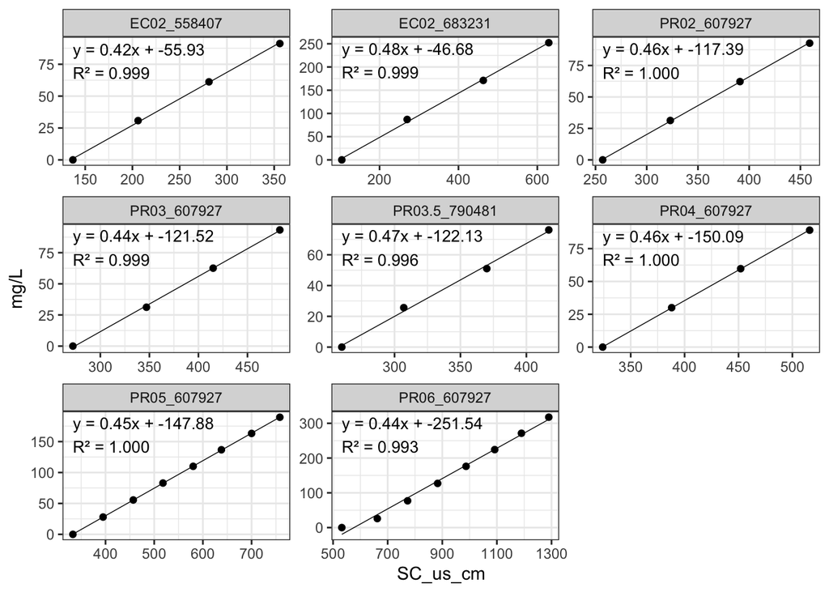

```r
# Calculate slope and R2 for each site_probe combination and add as columns
corr_dat <- corr_dat %>%
  group_by(site_probe) %>%
  dplyr::mutate(
    # Extract slope coefficient from linear model
    slope = coef(lm(`mg/L`~ SC_us_cm))[2],
    # Extract R-squared value from linear model summary
    r_squared = summary(lm(`mg/L` ~ SC_us_cm))$r.squared
  ) %>%
  ungroup()

# Compute regression stats per group for annotations
label_dat <- corr_dat %>%
  group_by(site_probe) %>%
  summarize(
    fit = list(lm(`mg/L` ~ SC_us_cm)),
    .groups = "drop"
  ) %>%
  mutate(
    slope = map_dbl(fit, ~ coef(.x)[2]),
    intercept = map_dbl(fit, ~ coef(.x)[1]),
    r2 = map_dbl(fit, ~ summary(.x)$r.squared),
    eq_label = sprintf("y = %.2fx + %.2f\nR² = %.3f", slope, intercept, r2)
  )

# Determine coordinates for placing text labels near top-left of each facet
coord_dat <- corr_dat %>%
  group_by(site_probe) %>%
  summarize(
    y_pos = max(`mg/L`, na.rm = TRUE),
    x_pos = min(SC_us_cm, na.rm = TRUE),
    .groups = "drop"
  ) %>%
  left_join(label_dat, by = "site_probe")


# Plot with facet_wrap and custom labels
ggplot(corr_dat, aes(y = `mg/L`, x = SC_us_cm)) +
  geom_point() +
  geom_smooth(method = "lm", se = FALSE, color = "black", lwd = .25) +
  geom_text(
    data = coord_dat,
    aes(x = x_pos, y = y_pos, label = eq_label),
    hjust = 0, vjust = 1, size = 3.5, inherit.aes = FALSE
  ) +
  facet_wrap(~ site_probe, scales = "free") +
  theme_bw() +
  theme(legend.position = "none")
```

```r
# join corr_dat to device_summary to get a k_factor for each file name

device_summary <- device_summary %>%
  left_join(corr_dat %>%
              mutate(probe_sn = as.character(probe_sn)) %>%
              group_by(site, probe_sn) %>%
              dplyr::summarize(slope = mean(slope)) %>%
              select(site, probe_sn, slope) ,
            by = c("site_name" = "site",
                   "device_sn" = "probe_sn"))
```

[output not shown]

```r
# view table of correlation data results
corr_dat %>%
  kable(
    caption = "Correction Factor Summary",
    digits = 2,
    col.names = gsub("_", " ", names(corr_dat)) %>% stringr::str_to_title()
  ) %>%
  kable_styling(
    bootstrap_options = c("striped", "hover", "condensed", "responsive"),
    full_width = FALSE,
    position = "center",
    font_size = 14
  ) %>%
  row_spec(0, bold = TRUE, color = "white", background = "#2C3E50") # Custom dark
```

Correction Factor Summary

| Probe Sn | Site | Sample Ml | Ml Sol Added | Conc Sol Added Mg Ml | Sc Us Cm | Mg Added | Cum Mg Added | Mg/L | Manual Slope | Site Probe | Slope | R Squared |
| --- | --- | --- | --- | --- | --- | --- | --- | --- | --- | --- | --- | --- |
| 683231 | EC02 | 282.3 | 0 | 5 | 104.3 | 0 | 0 | 0.00 | 0.48 | EC02_683231 | 0.48 | 1.00 |
| 683231 | EC02 | 287.3 | 5 | 5 | 270.0 | 25 | 25 | 87.02 | 0.48 | EC02_683231 | 0.48 | 1.00 |
| 683231 | EC02 | 292.3 | 5 | 5 | 463.0 | 25 | 50 | 171.06 | 0.48 | EC02_683231 | 0.48 | 1.00 |
| 683231 | EC02 | 297.3 | 5 | 5 | 629.0 | 25 | 75 | 252.27 | 0.48 | EC02_683231 | 0.48 | 1.00 |
| 607927 | PR02 | 317.5 | 0 | 5 | 257.0 | 0 | 0 | 0.00 | 0.46 | PR02_607927 | 0.46 | 1.00 |
| 607927 | PR02 | 319.5 | 2 | 5 | 323.0 | 10 | 10 | 31.30 | 0.46 | PR02_607927 | 0.46 | 1.00 |
| 607927 | PR02 | 321.5 | 2 | 5 | 391.0 | 10 | 20 | 62.21 | 0.46 | PR02_607927 | 0.46 | 1.00 |
| 607927 | PR02 | 323.5 | 2 | 5 | 459.0 | 10 | 30 | 92.74 | 0.46 | PR02_607927 | 0.46 | 1.00 |
| 607927 | PR03 | 318.6 | 0 | 5 | 272.0 | 0 | 0 | 0.00 | 0.44 | PR03_607927 | 0.44 | 1.00 |
| 607927 | PR03 | 320.6 | 2 | 5 | 347.0 | 10 | 10 | 31.19 | 0.44 | PR03_607927 | 0.44 | 1.00 |
| 607927 | PR03 | 319.6 | 2 | 5 | 415.0 | 10 | 20 | 62.58 | 0.44 | PR03_607927 | 0.44 | 1.00 |
| 607927 | PR03 | 321.6 | 2 | 5 | 483.0 | 10 | 30 | 93.28 | 0.44 | PR03_607927 | 0.44 | 1.00 |
| 607927 | PR04 | 330.9 | 0 | 5 | 324.0 | 0 | 0 | 0.00 | 0.46 | PR04_607927 | 0.46 | 1.00 |
| 607927 | PR04 | 332.9 | 2 | 5 | 388.0 | 10 | 10 | 30.04 | 0.46 | PR04_607927 | 0.46 | 1.00 |
| 607927 | PR04 | 334.9 | 2 | 5 | 452.0 | 10 | 20 | 59.72 | 0.46 | PR04_607927 | 0.46 | 1.00 |
| 607927 | PR04 | 336.9 | 2 | 5 | 516.0 | 10 | 30 | 89.05 | 0.46 | PR04_607927 | 0.46 | 1.00 |
| 607927 | PR05 | 355.7 | 0 | 5 | 333.0 | 0 | 0 | 0.00 | 0.44 | PR05_607927 | 0.45 | 1.00 |
| 607927 | PR05 | 357.7 | 2 | 5 | 395.0 | 10 | 10 | 27.96 | 0.44 | PR05_607927 | 0.45 | 1.00 |
| 607927 | PR05 | 359.7 | 2 | 5 | 457.0 | 10 | 20 | 55.60 | 0.44 | PR05_607927 | 0.45 | 1.00 |
| 607927 | PR05 | 361.7 | 2 | 5 | 518.0 | 10 | 30 | 82.94 | 0.44 | PR05_607927 | 0.45 | 1.00 |
| 607927 | PR05 | 363.7 | 2 | 5 | 580.0 | 10 | 40 | 109.98 | 0.44 | PR05_607927 | 0.45 | 1.00 |
| 607927 | PR05 | 365.7 | 2 | 5 | 638.0 | 10 | 50 | 136.72 | 0.44 | PR05_607927 | 0.45 | 1.00 |
| 607927 | PR05 | 367.7 | 2 | 5 | 700.0 | 10 | 60 | 163.18 | 0.44 | PR05_607927 | 0.45 | 1.00 |
| 607927 | PR05 | 369.7 | 2 | 5 | 758.0 | 10 | 70 | 189.34 | 0.44 | PR05_607927 | 0.45 | 1.00 |
| 607927 | PR06 | 383.3 | 0 | 5 | 532.0 | 0 | 0 | 0.00 | 0.44 | PR06_607927 | 0.44 | 0.99 |
| 607927 | PR06 | 385.3 | 2 | 5 | 662.0 | 10 | 10 | 25.95 | 0.44 | PR06_607927 | 0.44 | 0.99 |
| 607927 | PR06 | 389.3 | 4 | 5 | 773.0 | 20 | 30 | 77.06 | 0.44 | PR06_607927 | 0.44 | 0.99 |
| 607927 | PR06 | 393.3 | 4 | 5 | 883.0 | 20 | 50 | 127.13 | 0.44 | PR06_607927 | 0.44 | 0.99 |
| 607927 | PR06 | 397.3 | 4 | 5 | 987.0 | 20 | 70 | 176.19 | 0.44 | PR06_607927 | 0.44 | 0.99 |
| 607927 | PR06 | 401.3 | 4 | 5 | 1092.0 | 20 | 90 | 224.27 | 0.44 | PR06_607927 | 0.44 | 0.99 |
| 607927 | PR06 | 405.3 | 4 | 5 | 1190.0 | 20 | 110 | 271.40 | 0.44 | PR06_607927 | 0.44 | 0.99 |
| 607927 | PR06 | 409.3 | 4 | 5 | 1290.0 | 20 | 130 | 317.62 | 0.44 | PR06_607927 | 0.44 | 0.99 |
| 790481 | PR03.5 | 387.9 | 0 | 5 | 260.0 | 0 | 0 | 0.00 | 0.47 | PR03.5_790481 | 0.47 | 1.00 |
| 790481 | PR03.5 | 389.9 | 2 | 5 | 307.0 | 10 | 10 | 25.65 | 0.47 | PR03.5_790481 | 0.47 | 1.00 |
| 790481 | PR03.5 | 391.9 | 2 | 5 | 370.0 | 10 | 20 | 51.03 | 0.47 | PR03.5_790481 | 0.47 | 1.00 |
| 790481 | PR03.5 | 393.9 | 2 | 5 | 417.0 | 10 | 30 | 76.16 | 0.47 | PR03.5_790481 | 0.47 | 1.00 |
| 558407 | EC02 | 322.8 | 0 | 5 | 137.0 | 0 | 0 | 0.00 | 0.42 | EC02_558407 | 0.42 | 1.00 |
| 558407 | EC02 | 324.8 | 2 | 5 | 206.0 | 10 | 10 | 30.79 | 0.42 | EC02_558407 | 0.42 | 1.00 |
| 558407 | EC02 | 326.8 | 2 | 5 | 281.0 | 10 | 20 | 61.20 | 0.42 | EC02_558407 | 0.42 | 1.00 |
| 558407 | EC02 | 328.8 | 2 | 5 | 356.0 | 10 | 30 | 91.24 | 0.42 | EC02_558407 | 0.42 | 1.00 |

Now, we run an individual slug test to show how the code works. We observe a classic breakthrough curve. The function automatically determrines the background concentration. Note that slug mass can be adjusted here, but if left NULL, it is read automatically from the file name.

```r
# Update file path to change test

file_path <- "data/park/MORA/salt_slugs/MORA_Slugs_Sep1/PR04_01_600.csv"
log_name  <- get_log_name(file_path)  # whatever's after the last "/" and before ".csv"

# Salt mass (grams) is auto-detected from the file name — the segment
# after the final "_" and before ".csv" (e.g. "..._400.csv" -> 400 g).
# To override with a manually assigned mass instead, set a number here:
# slug_mass <- 400
slug_mass <- NULL

dt <- 1  # logger interval, seconds (should always be 1 sec before the slug)

# Which conductivity column to use: "specific_conductivity" (temperature-
# compensated) or "actual_conductivity" (raw reading). Matched flexibly
# against the column names, so it's fine if units or the sensor serial
# number in the column name differ between loggers.
cond_type <- "specific_conductivity"

# Background conductivity is auto-detected from the stable period before
# breakthrough. To override with a manually read value instead, set:
# bck_cond <- 597

# Correction factor +/- range (uS/cm -> mg/L uncertainty). Set to NULL to
# report only the point estimate. Can also be a specific low/high pair,
# e.g. c(0.47, 0.53).
correction_factor       <- device_summary %>%
                            filter(file_name == paste0(log_name,".csv")) %>%
                          pull(slope)

correction_factor_range <- c(correction_factor * 0.95, correction_factor * 1.05)#c(0.41, 0.47)

# ---------------------------------------------------------------------------- #
# Run
# ---------------------------------------------------------------------------- #
raw_data <- read_slug_log(file_path)

result <- run_salt_slug(
  data = raw_data,
  slug_mass = slug_mass,   # NULL -> auto-detected from file_path's file name
  file_path = file_path,
  cond_type = cond_type,
  correction_factor = correction_factor,
  correction_factor_range = correction_factor_range,
  dt = dt
  # bck_cond = bck_cond   # uncomment to override auto-detection
)
sensor_data          <- result$sensor_data
discharge_Ls         <- result$discharge_Ls
discharge_cfs        <- result$discharge_cfs
discharge_range_Ls   <- result$discharge_range_Ls
discharge_range_cfs  <- result$discharge_range_cfs
bck_cond             <- result$bck_cond
breakthrough_time    <- result$breakthrough_time

cat(str_glue("Slug mass used: {result$slug_mass} g\n"))
```

```
## Slug mass used: 600 g
```

```r
cat(str_glue("Detected background conductivity: {round(bck_cond, 1)} uS/cm\n"))
```

```
## Detected background conductivity: 315.9 uS/cm
```

```r
cat(str_glue("Breakthrough started at: {breakthrough_time}\n"))
```

```
## Breakthrough started at: 2026-09-01 14:03:47
```

```r
cat(str_glue("Discharge: {format_discharge_label(discharge_Ls, discharge_cfs, discharge_range_Ls, discharge_range_cfs)}\n"))
```

```
## Discharge: 82.139 L/s (78.228–86.462)   |   2.901 ft³/s (2.763–3.053)
```

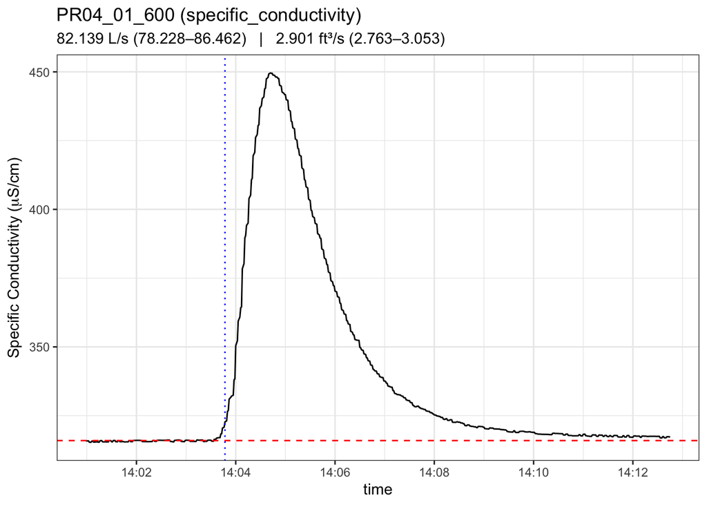

```r
breakthrough_curve <- plot_breakthrough(
  sensor_data, bck_cond, discharge_Ls, discharge_cfs, log_name,
  breakthrough_time = breakthrough_time,
  discharge_range_Ls = discharge_range_Ls,
  discharge_range_cfs = discharge_range_cfs,
  cond_type = cond_type
)
breakthrough_curve
```